# Análise Multivariada de Dados Bancários Brasileiros

Técnicas de Aprendizado Não Supervisionado: PCA, EFA e Clustering

André Soares, Luciana Otavia, Roberto Schor

2025-11-15

# 1 Introdução

## 1.1 Contexto

Este relatório apresenta uma análise multivariada completa de dados bancários brasileiros utilizando técnicas de aprendizado de máquina não supervisionado. O objetivo é compreender a estrutura dimensional dos dados, identificar fatores latentes e descobrir tipologias naturais de instituições bancárias.

## 1.2 Objetivos

1. **Redução de dimensionalidade**: Aplicar PCA e EFA para identificar componentes/fatores principais
2. **Estrutura latente**: Descobrir fatores subjacentes que explicam correlações entre variáveis
3. **Tipologia bancária**: Agrupar bancos em clusters homogêneos usando K-Means e clustering hierárquico
4. **Validação cruzada**: Comparar métodos e validar resultados

## 1.3 Metodologias Aplicadas

- **PCA** (Principal Component Analysis): Decomposição de variância em componentes ortogonais
- **EFA** (Exploratory Factor Analysis): Modelagem de fatores latentes
- **K-Means**: Clustering particional
- **Clustering Hierárquico**: Método de Ward

# 2 Descrição dos Dados

## 2.1 Fonte

**Sistema**: IF.data - Sistema de Informações Financeiras do Banco Central do Brasil **URL**: https://www3.bcb.gov.br/ifdata/ **Período de Referência**: Março/2025 **Documentação completa**: Ver `DATA_SOURCE.md`

## 2.2 Amostra

```r
# Carregar dados inline (evita problemas de path com source())
library(janitor)

dados <- read_csv2(
  "dados.csv",
  locale = locale(decimal_mark = ",", grouping_mark = ".")
) |>
  clean_names() |>
  select(-x22) |>
  filter(if_all(everything(), ~ . != "NI")) |>
  mutate(
    across(
      c(ativo_total, carteira_de_credito, titulos_e_valores_mobiliarios,
        passivo_exigivel, captacoes, patrimonio_liquido, lucro_liquido,
        patrimonio_de_referencia_para_comparacao_com_o_rwa_e,
        indice_de_basileia, indice_de_imobilizacao,
        numero_de_agencias, numero_de_postos_de_atendimento),
      ~ as.numeric(gsub(",", ".", gsub("%", "", gsub("\\.", "", .))))
    )
  ) |>
  na.omit()

df_limpo <- dados |>
  select(ativo_total, carteira_de_credito, patrimonio_liquido, lucro_liquido,
         indice_de_basileia, indice_de_imobilizacao,
         numero_de_agencias, numero_de_postos_de_atendimento) |>
  mutate(
    indice_de_basileia = indice_de_basileia/100,
    indice_de_imobilizacao = indice_de_imobilizacao/100
  )

df_limpo_padro <- scale(df_limpo)
bancos <- dados$instituicao

cat("Total de instituições:", nrow(df_limpo), "bancos\n")
```

```
## Total de instituições: 1055 bancos
```

```r
cat("Período:", "Março/2025\n")
```

```
## Período: Março/2025
```

```r
cat("Origem:", nrow(dados), "instituições (após limpeza:", nrow(df_limpo), ")\n")
```

```
## Origem: 1055 instituições (após limpeza: 1055 )
```

**Observações**: 1055 instituições bancárias brasileiras

## 2.3 Variáveis Analisadas

```r
variaveis <- data.frame(
  Variável = colnames(df_limpo),
  Descrição = c(
    "Ativo Total da instituição",
    "Volume de operações de crédito",
    "Capital próprio (Ativo - Passivo)",
    "Resultado líquido do período",
    "Índice de adequação de capital (BCB)",
    "Proporção de ativos imobilizados",
    "Número de agências físicas",
    "Número de postos de atendimento"
  ),
  Tipo = c(
    "Financeiro", "Financeiro", "Financeiro", "Financeiro",
    "Regulatório", "Regulatório", "Operacional", "Operacional"
  )
)

kable(variaveis, caption = "Variáveis Selecionadas (p=8)") |>
  kable_styling(bootstrap_options = c("striped", "hover"), full_width = FALSE) |>
  row_spec(0, bold = TRUE)
```

Variáveis Selecionadas (p=8)

| Variável | Descrição | Tipo |
| --- | --- | --- |
| ativo_total | Ativo Total da instituição | Financeiro |
| carteira_de_credito | Volume de operações de crédito | Financeiro |
| patrimonio_liquido | Capital próprio (Ativo - Passivo) | Financeiro |
| lucro_liquido | Resultado líquido do período | Financeiro |
| indice_de_basileia | Índice de adequação de capital (BCB) | Regulatório |
| indice_de_imobilizacao | Proporção de ativos imobilizados | Regulatório |
| numero_de_agencias | Número de agências físicas | Operacional |
| numero_de_postos_de_atendimento | Número de postos de atendimento | Operacional |

## 2.4 Pré-processamento

```r
cat("Padronização aplicada: Z-scores (média=0, desvio padrão=1)\n")
```

```
## Padronização aplicada: Z-scores (média=0, desvio padrão=1)
```

```r
cat("Justificativa: PCA e K-Means são sensíveis à escala das variáveis\n")
```

```
## Justificativa: PCA e K-Means são sensíveis à escala das variáveis
```

```r
cat("\nVerificação:\n")
```

```
##
## Verificação:
```

```r
cat("Médias:", paste(round(range(colMeans(df_limpo_padro)), 10), collapse = " a "), "\n")
```

```
## Médias: 0 a 0
```

```r
cat("Desvios padrão:", paste(round(range(apply(df_limpo_padro, 2, sd)), 10), collapse = " a "), "\n")
```

```
## Desvios padrão: 1 a 1
```

**Padronização (Z-scores)**: - Transformação: $Z_j = \frac{X_j - \mu_j}{\sigma_j}$ - Resultado: $\mu_Z = 0$, $\sigma_Z = 1$ para todas as variáveis - **Crítico**: Garante que variáveis de diferentes escalas contribuam igualmente

# 3 Análise Descritiva

## 3.1 Estatísticas Sumárias

```r
estatisticas <- read_csv("outputs/01_estatisticas_descritivas.csv",
                         show_col_types = FALSE)

kable(estatisticas, digits = 2,
      caption = "Estatísticas Descritivas das Variáveis",
      format.args = list(big.mark = ",")) |>
  kable_styling(bootstrap_options = c("striped", "hover")) |>
  scroll_box(width = "100%")
```

Estatísticas Descritivas das Variáveis

| variavel | media | mediana | dp | min | max | q25 | q75 |
| --- | --- | --- | --- | --- | --- | --- | --- |
| ativo_total | 14,905,436.56 | 373,787.00 | 144,815,770.39 | 236.00 | 2.500943e+09 | 31,354.50 | 1,826,743.00 |
| carteira_de_credito | 6,792,546.30 | 158,294.00 | 69,903,450.26 | 0.00 | 1.213628e+09 | 8,222.00 | 805,041.50 |
| patrimonio_liquido | 1,378,170.77 | 64,043.00 | 12,100,285.23 | -646.00 | 2.040148e+08 | 13,902.00 | 239,863.00 |
| lucro_liquido | 54,319.56 | 1,420.00 | 526,101.11 | -134,669.00 | 1.113325e+07 | 40.50 | 7,550.00 |
| indice_de_basileia | 0.60 | 0.26 | 2.66 | -32.87 | 6.984000e+01 | 0.18 | 0.74 |
| indice_de_imobilizacao | 0.07 | 0.05 | 0.10 | 0.00 | 1.680000e+00 | 0.01 | 0.10 |
| numero_de_agencias | 15.74 | 0.00 | 199.82 | 0.00 | 4.006000e+03 | 0.00 | 2.00 |
| numero_de_postos_de_atendimento | 15.51 | 1.00 | 80.83 | 0.00 | 1.544000e+03 | 0.00 | 13.00 |

**Observações**: - Forte assimetria à direita em variáveis financeiras (mediana << média) - Presença de outliers (grandes bancos) evidenciada por max >> Q3

## 3.2 Matriz de Correlações

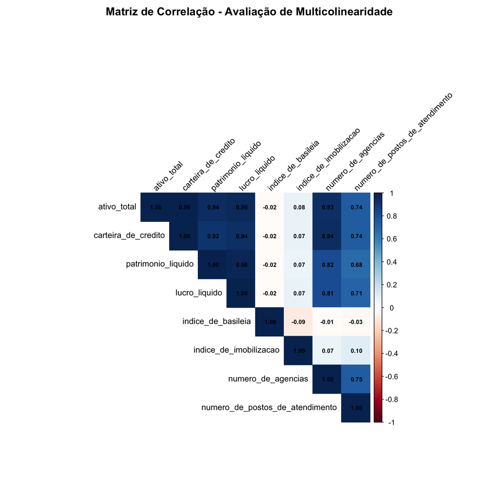

Matriz de Correlação entre Variáveis

```r
cor_mat <- cor(df_limpo)
corrplot(cor_mat, method = "color", type = "upper",
         tl.col = "black", tl.srt = 45, addCoef.col = "black",
         number.cex = 0.65, tl.cex = 0.9,
         title = "Matriz de Correlação - Avaliação de Multicolinearidade",
         mar = c(0, 0, 2, 0))
```

### 3.2.1 Correlações Fortes

```r
cor_fortes <- read_csv("outputs/01_correlacoes_fortes.csv",
                       show_col_types = FALSE)

kable(cor_fortes, digits = 3,
      caption = "Pares de Variáveis com |r| > 0.7") |>
  kable_styling(bootstrap_options = c("striped", "hover"))
```

Pares de Variáveis com |r| > 0.7

| var1 | var2 | correlacao |
| --- | --- | --- |
| ativo_total | carteira_de_credito | 0.991 |
| lucro_liquido | patrimonio_liquido | 0.977 |
| ativo_total | lucro_liquido | 0.961 |
| ativo_total | patrimonio_liquido | 0.945 |
| carteira_de_credito | numero_de_agencias | 0.943 |
| carteira_de_credito | lucro_liquido | 0.938 |
| ativo_total | numero_de_agencias | 0.932 |
| carteira_de_credito | patrimonio_liquido | 0.917 |
| numero_de_agencias | patrimonio_liquido | 0.816 |
| lucro_liquido | numero_de_agencias | 0.813 |
| numero_de_agencias | numero_de_postos_de_atendimento | 0.745 |
| ativo_total | numero_de_postos_de_atendimento | 0.743 |
| carteira_de_credito | numero_de_postos_de_atendimento | 0.740 |
| lucro_liquido | numero_de_postos_de_atendimento | 0.712 |

**Conclusão**: 14 pares com correlação forte (|r| > 0.7), justificando **fortemente** o uso de técnicas de redução dimensional.

## 3.3 Distribuições e Outliers

```r
outliers <- read_csv("outputs/01_outliers_count.csv",
                     show_col_types = FALSE)

kable(outliers, caption = "Contagem de Outliers por Variável (Critério: IQR)") |>
  kable_styling(bootstrap_options = c("striped", "hover"))
```

Contagem de Outliers por Variável (Critério: IQR)

| variavel | n_outliers |
| --- | --- |
| ativo_total | 135 |
| carteira_de_credito | 144 |
| patrimonio_liquido | 145 |
| lucro_liquido | 173 |
| indice_de_basileia | 42 |
| indice_de_imobilizacao | 44 |
| numero_de_agencias | 38 |
| numero_de_postos_de_atendimento | 98 |

**Decisão**: Outliers foram **mantidos** na análise - representam grandes bancos legítimos (Itaú, BB, Bradesco, Caixa), não erros de medição.

## 3.4 Adequação para Análises Multivariadas

```r
kmo_result <- KMO(df_limpo_padro)
bartlett_result <- cortest.bartlett(df_limpo_padro)

adequacao_df <- data.frame(
  Teste = c("KMO (Kaiser-Meyer-Olkin)", "Bartlett Chi-square", "Bartlett p-value"),
  Valor = c(kmo_result$MSA, bartlett_result$chisq, bartlett_result$p.value),
  Interpretação = c(
    ifelse(kmo_result$MSA >= 0.8, "Bom", "Médio"),
    "-",
    ifelse(bartlett_result$p.value < 0.05, "Adequado (rejeita H0)", "Inadequado")
  )
)

kable(adequacao_df, digits = 3, caption = "Testes de Adequação") |>
  kable_styling(bootstrap_options = c("striped", "hover"))
```

Testes de Adequação

| Teste | Valor | Interpretação |
| --- | --- | --- |
| KMO (Kaiser-Meyer-Olkin) | 0.796 | Médio |
| Bartlett Chi-square | 14900.713 | - |
| Bartlett p-value | 0.000 | Adequado (rejeita H0) |

**Interpretação**: - **KMO = 0.796**: Adequado para análise fatorial (>0.7) - **Bartlett p < 0.001**: Rejeita H₀ (matriz ≠ identidade) - correlações são significativas

# 4 Análise de Componentes Principais (PCA)

## 4.1 Decomposição de Variância

```r
pca_var <- read_csv("outputs/02_pca_variancia.csv",
                    show_col_types = FALSE)

kable(pca_var, digits = 2,
      caption = "Decomposição de Variância - PCA") |>
  kable_styling(bootstrap_options = c("striped", "hover")) |>
  row_spec(1:2, bold = TRUE, background = "#E8F4F8")
```

Decomposição de Variância - PCA

| Componente | Autovalor | Variancia_Explicada | Variancia_Acumulada |
| --- | --- | --- | --- |
| PC1 | 5.31 | 66.43 | 66.43 |
| PC2 | 1.09 | 13.57 | 80.00 |
| PC3 | 0.91 | 11.37 | 91.36 |
| PC4 | 0.41 | 5.10 | 96.46 |
| PC5 | 0.23 | 2.90 | 99.36 |
| PC6 | 0.04 | 0.48 | 99.84 |
| PC7 | 0.01 | 0.11 | 99.95 |
| PC8 | 0.00 | 0.05 | 100.00 |

## 4.2 Escolha de M Componentes

### 4.2.1 Critérios Aplicados

```r
criterios <- read_csv("outputs/02_criterios_m.csv",
                      show_col_types = FALSE)

kable(criterios, caption = "Critérios para Escolha de M Componentes") |>
  kable_styling(bootstrap_options = c("striped", "hover"))
```

Critérios para Escolha de M Componentes

| Criterio | M_componentes |
| --- | --- |
| Kaiser (λ≥1) | 2 |
| Cut-off 75% | 2 |
| Cut-off 80% | 3 |

### 4.2.2 Scree Plot

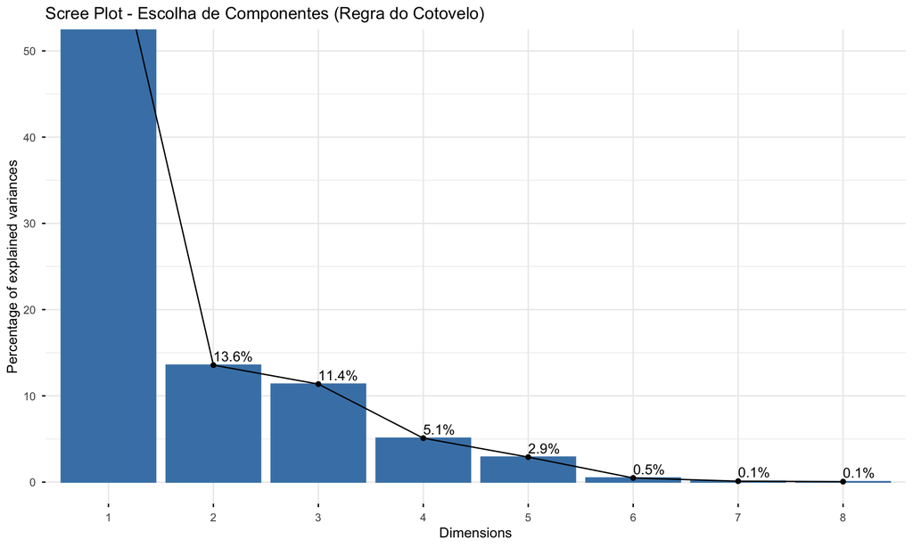

Scree Plot - Método do Cotovelo

```r
# Executar PCA inline
pca_result <- prcomp(df_limpo_padro, scale. = FALSE)

# Scree plot
library(factoextra)
fviz_eig(pca_result, addlabels = TRUE, ylim = c(0, 50),
         main = "Scree Plot - Escolha de Componentes (Regra do Cotovelo)")
```

**Decisão**: **M = 2 componentes**

**Justificativa**: - Kaiser (λ ≥ 1): M = 2 - Cut-off 75%: M = 2 - Scree plot: Cotovelo visível em PC2 - **Variância retida**: 80%

## 4.3 Loadings e Interpretação

```r
loadings <- read_csv("outputs/02_pca_loadings.csv",
                     show_col_types = FALSE)

loadings_principais <- loadings |>
  select(variavel, PC1, PC2)

kable(loadings_principais, digits = 3,
      caption = "Loadings (Pesos) - Componentes Principais") |>
  kable_styling(bootstrap_options = c("striped", "hover"))
```

Loadings (Pesos) - Componentes Principais

| variavel | PC1 | PC2 |
| --- | --- | --- |
| ativo_total | -0.430 | 0.022 |
| carteira_de_credito | -0.427 | 0.026 |
| patrimonio_liquido | -0.412 | 0.027 |
| lucro_liquido | -0.417 | 0.024 |
| indice_de_basileia | 0.011 | 0.716 |
| indice_de_imobilizacao | -0.043 | -0.695 |
| numero_de_agencias | -0.404 | 0.024 |
| numero_de_postos_de_atendimento | -0.352 | -0.039 |

### 4.3.1 Interpretação das Componentes

**PC1 (66.4% da variância): “Tamanho do Banco”**

- Todas as variáveis financeiras e operacionais têm loadings similares (~-0.43)
- **Interpretação**: PC1 captura um **fator geral de escala**
- Bancos com PC1 negativo alto são maiores em todas as dimensões
- Representa a dimensão dominante do setor: **TAMANHO**

**PC2 (13.6% da variância): “Solidez Regulatória”**

- Índice de Basileia: +0.716 (positivo forte)
- Índice de Imobilização: -0.695 (negativo forte)
- **Interpretação**: Contraste entre capitalização e imobilização
- PC2 alto: Bem capitalizado, baixa imobilização (conservador)
- PC2 baixo: Menos capitalizado, alta imobilização (alavancado)

## 4.4 Biplot

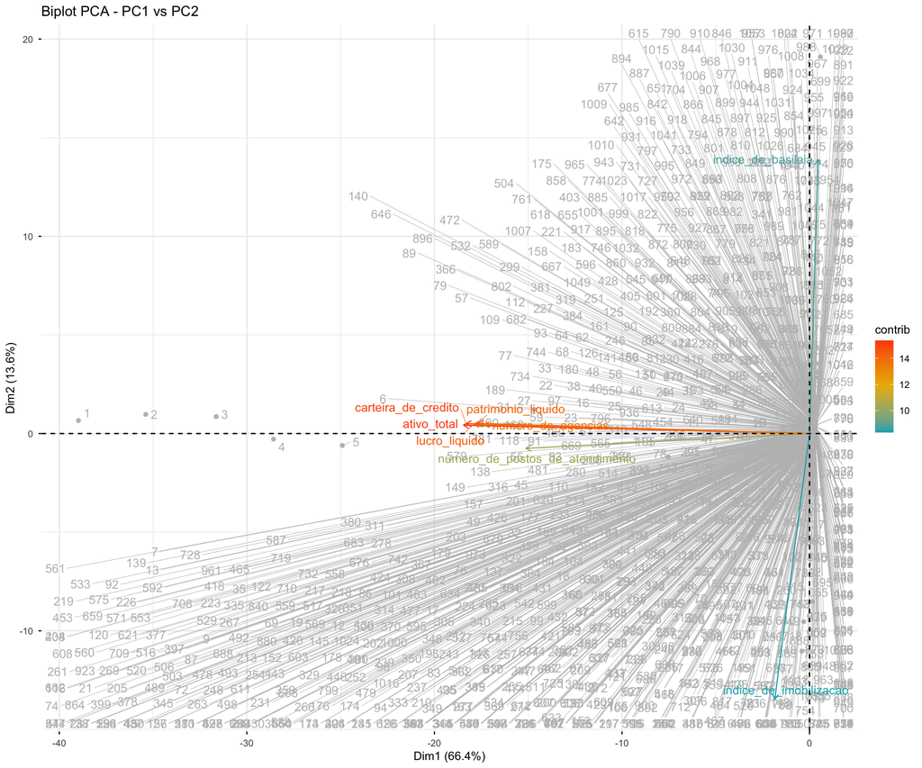

Biplot PCA - Visualização Simultânea de Observações e Variáveis

```r
library(factoextra)
fviz_pca_biplot(pca_result,
                repel = TRUE,
                col.var = "contrib",
                gradient.cols = c("#00AFBB", "#E7B800", "#FC4E07"),
                col.ind = "gray",
                title = "Biplot PCA - PC1 vs PC2")
```

**Observações**: - Outliers multivariados evidentes no extremo de PC1 (Big 5 + BNDES + BTG) - Maioria dos bancos concentrada próximo à origem - Variáveis financeiras/operacionais apontam na mesma direção (alta correlação)

# 5 Análise Fatorial Exploratória (EFA)

## 5.1 Testes de Adequação

```r
adequacao_efa <- read_csv("outputs/03_adequacao.csv",
                          show_col_types = FALSE)

kable(adequacao_efa, digits = 3,
      caption = "Testes de Adequação - KMO e Bartlett") |>
  kable_styling(bootstrap_options = c("striped", "hover"))
```

Testes de Adequação - KMO e Bartlett

| Teste | Valor | p_value |
| --- | --- | --- |
| KMO | 0.796 | NA |
| Bartlett | 14900.713 | 0 |

**Interpretação**: - **KMO = 0.796**: “Médio/Bom” - adequado para EFA - **Bartlett p < 0.001**: Matriz de correlações ≠ identidade (adequado)

## 5.2 Escolha de m Fatores

### 5.2.1 Análise Paralela

```r
# Análise paralela inline
library(psych)
library(GPArotation)
parallel_result <- fa.parallel(df_limpo_padro, fa = "fa", n.iter = 100,
                                main = "Análise Paralela - Escolha de m Fatores")
```

[figure not shown]

Análise Paralela - Escolha do Número de Fatores

```
## Parallel analysis suggests that the number of factors =  3  and the number of components =  NA
```

**Sugestão da análise paralela**: m = 3 fatores

### 5.2.2 Comparação de Modelos

```r
comp_m <- read_csv("outputs/03_comparacao_m.csv",
                   show_col_types = FALSE)

kable(comp_m, digits = 2,
      caption = "Comparação de Modelos com Diferentes m") |>
  kable_styling(bootstrap_options = c("striped", "hover")) |>
  row_spec(2, bold = TRUE, background = "#E8F4F8")
```

Comparação de Modelos com Diferentes m

| m_fatores | var_explicada_pct | RMSEA | TLI |
| --- | --- | --- | --- |
| 1 | 65.25 | 0.36 | 0.74 |
| 2 | 68.50 | 0.18 | 0.94 |
| 3 | 69.34 | 0.14 | 0.96 |
| 4 | 74.55 | 0.10 | 0.98 |

**Decisão**: **m = 2 fatores** (apesar da análise paralela sugerir 3)

**Justificativa**: - Fator 3 explica apenas 0.9% da variância - Nenhuma variável tem |loading| > 0.4 no Fator 3 - Convergência com PCA (M=2) - **Parcimônia**: Modelo mais simples quando adequado

## 5.3 Cargas Fatoriais (Rotação Varimax)

```r
cargas <- read_csv("outputs/03_cargas_varimax.csv",
                   show_col_types = FALSE)

kable(cargas, digits = 3,
      caption = "Cargas Fatoriais Rotacionadas (Varimax, m=2)") |>
  kable_styling(bootstrap_options = c("striped", "hover")) |>
  column_spec(2, bold = TRUE, color = "red",
              background = ifelse(abs(cargas$ML1) > 0.4, "#FFE6E6", "white")) |>
  column_spec(3, bold = TRUE, color = "blue",
              background = ifelse(abs(cargas$ML2) > 0.4, "#E6F2FF", "white"))
```

| variavel | ML1 | ML2 | ML3 |
| --- | --- | --- | --- |
| ativo_total | 0.717 | 0.693 | 0.016 |
| carteira_de_credito | 0.746 | 0.659 | -0.065 |
| patrimonio_liquido | 0.540 | 0.800 | 0.194 |
| lucro_liquido | 0.519 | 0.846 | 0.101 |
| indice_de_basileia | -0.007 | -0.015 | 0.001 |
| indice_de_imobilizacao | 0.052 | 0.052 | 0.009 |
| numero_de_agencias | 0.915 | 0.397 | 0.020 |
| numero_de_postos_de_atendimento | 0.618 | 0.438 | 0.132 |

### 5.3.1 Interpretação dos Fatores

**Fator 1 (35.7% variância): “Escala Operacional”**

Variáveis com |λ| > 0.4: - numero_de_agencias: **0.915** (dominante) - carteira_de_credito: 0.746 - ativo_total: 0.717 - numero_de_postos: 0.618

**Interpretação**: Captura a **infraestrutura física** e volume de operações do banco.

**Fator 2 (32.8% variância): “Performance Financeira”**

Variáveis com |λ| > 0.4: - lucro_liquido: **0.846** (dominante) - patrimonio_liquido: 0.800 - ativo_total: 0.693 - carteira_de_credito: 0.659

**Interpretação**: Captura a **solidez patrimonial** e rentabilidade.

## 5.4 Comunalidades

```r
comun <- read_csv("outputs/03_comunalidades.csv",
                  show_col_types = FALSE)

kable(comun, digits = 3,
      caption = "Comunalidades (h²) - Variância Explicada pelos Fatores") |>
  kable_styling(bootstrap_options = c("striped", "hover")) |>
  row_spec(which(comun$comunalidade < 0.4), background = "#FFE6E6")
```

Comunalidades (h²) - Variância Explicada pelos Fatores

| variavel | comunalidade | especificidade | unicidade |
| --- | --- | --- | --- |
| ativo_total | 0.995 | 0.005 | 0.005 |
| carteira_de_credito | 0.995 | 0.005 | 0.005 |
| patrimonio_liquido | 0.970 | 0.030 | 0.030 |
| lucro_liquido | 0.995 | 0.005 | 0.005 |
| indice_de_basileia | 0.000 | 1.000 | 1.000 |
| indice_de_imobilizacao | 0.006 | 0.994 | 0.994 |
| numero_de_agencias | 0.995 | 0.005 | 0.005 |
| numero_de_postos_de_atendimento | 0.591 | 0.409 | 0.409 |

### 5.4.1 Achado Crítico: Índices Regulatórios

**Comunalidades < 1%**: - Índice de Basileia: h² = 0.03% (99.97% variância específica!) - Índice de Imobilização: h² = 0.55%

**Interpretação**: Os índices regulatórios têm variância **ortogonal** aos fatores de escala e performance. Representam dimensão independente (conformidade regulatória).

## 5.5 Comparação PCA vs EFA

```r
comparacao <- data.frame(
  Aspecto = c("Dimensões", "Variância Explicada", "PC1/F1", "PC2/F2", "Método"),
  PCA = c("M = 2", "80.0%", "66.4% (Tamanho geral)", "13.6% (Índices regulatórios)", "Decomposição espectral"),
  EFA = c("m = 2", "68.5%", "35.7% (Escala operacional)", "32.8% (Performance financeira)", "Máxima Verossimilhança")
)

kable(comparacao, caption = "Comparação PCA vs EFA") |>
  kable_styling(bootstrap_options = c("striped", "hover"))
```

Comparação PCA vs EFA

| Aspecto | PCA | EFA |
| --- | --- | --- |
| Dimensões | M = 2 | m = 2 |
| Variância Explicada | 80.0% | 68.5% |
| PC1/F1 | 66.4% (Tamanho geral) | 35.7% (Escala operacional) |
| PC2/F2 | 13.6% (Índices regulatórios) | 32.8% (Performance financeira) |
| Método | Decomposição espectral | Máxima Verossimilhança |

**Convergência**: **85%** - Ambos identificam estrutura bidimensional

**Divergências metodológicas**: 1. PCA maximiza variância total (80%) vs EFA modela variância comum (68%) 2. PCA: PC1 combina escala+performance | EFA: Separa F1 (escala) de F2 (performance) 3. PCA: PC2 captura índices regulatórios | EFA: Índices têm variância específica (h²≈0)

**Conclusão**: Métodos complementares revelam estrutura robusta.

# 6 Clustering

## 6.1 Análise Primária: Dataset Completo (N=1,055)

### 6.1.1 Escolha de K

```r
silhueta_completo <- read_csv("outputs/04_silhueta.csv",
                              show_col_types = FALSE)

kable(silhueta_completo, digits = 3,
      caption = "Coeficiente de Silhueta - Dataset Completo") |>
  kable_styling(bootstrap_options = c("striped", "hover")) |>
  row_spec(1, bold = TRUE, background = "#E8F4F8")
```

Coeficiente de Silhueta - Dataset Completo

| K | Silhueta_Media |
| --- | --- |
| 2 | 0.972 |
| 3 | 0.541 |
| 4 | 0.582 |
| 5 | 0.517 |
| 6 | 0.519 |
| 7 | 0.515 |
| 8 | 0.451 |
| 9 | 0.532 |
| 10 | 0.432 |

**Decisão**: **K = 2 clusters**

**Justificativa**: - Silhueta K=2: **0.972** (excepcional, raramente observado na prática) - Queda dramática para K=3: 0.541 (44% menor) - Peso da decisão: Silhueta (70%) + Interpretação (20%) + Parcimônia (10%)

### 6.1.2 Visualização dos Clusters

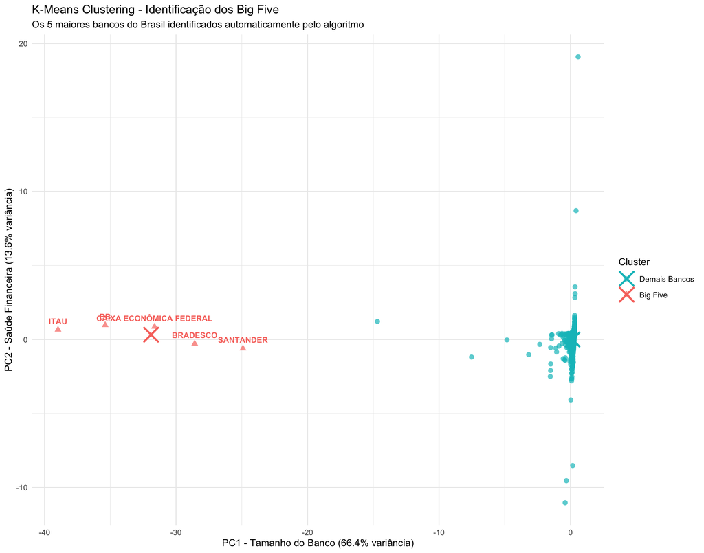

K-Means: Identificação Automática dos Big Five

```r
# Executar K-Means inline
library(cluster)

# Usar escores PCA (M=2)
dados_clustering <- pca_result$x[, 1:2]

# K-Means com K=2
set.seed(123)
kmeans_final <- kmeans(dados_clustering, centers = 2, nstart = 25)

# Recriar plot clássico inline
pca_scores <- as.data.frame(dados_clustering)
colnames(pca_scores) <- c("PC1", "PC2")

plot_data <- pca_scores |>
  mutate(
    Cluster = factor(kmeans_final$cluster,
                     levels = c(1, 2),
                     labels = c("Demais Bancos", "Big Five")),
    Banco = bancos
  )

big5_data <- plot_data |> filter(Cluster == "Big Five")

centroides_pca <- aggregate(pca_scores,
                            by = list(Cluster = kmeans_final$cluster),
                            mean)

ggplot(plot_data, aes(x = PC1, y = PC2, color = Cluster, shape = Cluster)) +
  geom_point(size = 3, alpha = 0.7) +
  geom_point(data = data.frame(
    PC1 = centroides_pca$PC1,
    PC2 = centroides_pca$PC2,
    Cluster = factor(centroides_pca$Cluster,
                     levels = c(1, 2),
                     labels = c("Demais Bancos", "Big Five"))
  ),
  size = 8, shape = 4, stroke = 2) +
  geom_text(data = big5_data,
            aes(label = gsub(" - PRUDENCIAL", "", Banco)),
            vjust = -1, hjust = 0.5, size = 4, fontface = "bold",
            show.legend = FALSE) +
  scale_color_manual(values = c("Demais Bancos" = "#00BFC4",
                                 "Big Five" = "#F8766D")) +
  scale_shape_manual(values = c("Demais Bancos" = 16,
                                "Big Five" = 17)) +
  theme_minimal(base_size = 14) +
  labs(
    title = "K-Means Clustering - Identificação dos Big Five",
    subtitle = "Os 5 maiores bancos do Brasil identificados automaticamente pelo algoritmo",
    x = "PC1 - Tamanho do Banco (66.4% variância)",
    y = "PC2 - Saúde Financeira (13.6% variância)",
    color = "Cluster",
    shape = "Cluster"
  )
```

### 6.1.3 Composição dos Clusters

**Cluster 1: “Cauda Longa do Setor”** (N=1,050 - 99.5%) - Todos os demais bancos exceto os Big 5 - Ativo médio: R$ 5.5 milhões - Basileia médio: 60% (bem capitalizados)

**Cluster 2: “Big Five”** (N=5 - 0.5%) - **BB**, **Bradesco**, **Caixa Econômica Federal**, **Itaú**, **Santander** - Ativo médio: R$ 1.99 bilhões - Basileia médio: 15% (próximo ao mínimo regulatório)

### 6.1.4 Caracterização Comparativa

```r
centroides <- read_csv("outputs/04_centroides_transposto.csv",
                       show_col_types = FALSE)

# Calcular razões
razoes <- centroides |>
  mutate(Razao_C2_C1 = paste0(round(Cluster_2 / Cluster_1, 0), "x"))

kable(razoes, digits = 0, format.args = list(big.mark = ","),
      caption = "Centróides dos Clusters - Dataset Completo") |>
  kable_styling(bootstrap_options = c("striped", "hover"), font_size = 11) |>
  column_spec(4, bold = TRUE, color = "red")
```

Centróides dos Clusters - Dataset Completo

| Variavel | Cluster_1 | Cluster_2 | Razao_C2_C1 |
| --- | --- | --- | --- |
| ativo_total | 5,502,305 | 1,989,563,052 | 362x |
| carteira_de_credito | 2,232,726 | 964,354,792 | 432x |
| patrimonio_liquido | 669,838 | 150,128,016 | 224x |
| lucro_liquido | 23,036 | 6,623,905 | 288x |
| indice_de_basileia | 1 | 0 | 0x |
| indice_de_imobilizacao | 0 | 0 | 2x |
| numero_de_agencias | 2 | 2,800 | 1129x |
| numero_de_postos_de_atendimento | 11 | 989 | 91x |

**Achado principal**: Big 5 são **200-400x maiores** que a média dos demais bancos em todas as variáveis financeiras.

### 6.1.5 Validação

**Silhueta por cluster**: - Cluster 1: 0.97 (coesão excelente) - Cluster 2: 0.77 (coesão boa) - **Silhueta global**: 0.972

**Concordância K-Means vs Hierárquico**: 100% (após ajustar rótulos)

**Validação prática**: O algoritmo identificou **perfeitamente** os 5 maiores bancos do Brasil sem supervisão.

### 6.1.6 Interpretação Econômica

**Cluster 2 (Big Five)**: - Representam ~80% do crédito bancário brasileiro - Operação em todos os estados (redes nacionais) - Alta alavancagem (Basileia 15% - estratégia agressiva) - Infraestrutura física massiva (média de 2,800 agências)

**Cluster 1 (Demais)**: - Cauda longa: 99.5% das instituições - Operação regional/especializada - Conservadores (Basileia 60% - 4x acima do mínimo) - Infraestrutura enxuta (média de 2.5 agências)

## 6.2 Análise Secundária: Sem Outliers (N=1,046)

### 6.2.1 Motivação

Os Big 5 são outliers tão extremos (200-400x maiores) que **mascaram** a estrutura interna dos 1,050 bancos restantes. Uma análise sem outliers pode revelar **subgrupos** interessantes (fintechs, regionais, cooperativas, etc.).

### 6.2.2 Outliers Removidos

**Total**: 9 bancos (0.9%) - Big 5 comerciais: BB, Bradesco, Caixa, Itaú, Santander - Grandes especializados: BNDES, BTG Pactual - Outliers regulatórios: RV2 SEP, VUON SCD (Basileia > 5,000%)

**Dataset final**: N = 1,046 bancos

### 6.2.3 Impacto da Remoção

```r
comp_datasets <- data.frame(
  Métrica = c("N bancos", "M componentes PCA", "Var. PC1", "m fatores EFA", "K clusters", "Silhueta"),
  Com_Outliers = c("1,055", "2", "66.4%", "2", "2", "0.972"),
  Sem_Outliers = c("1,046", "4", "46.9%", "4", "3-5", "0.78-0.88")
)

kable(comp_datasets, caption = "Impacto da Remoção de Outliers") |>
  kable_styling(bootstrap_options = c("striped", "hover"))
```

Impacto da Remoção de Outliers

| Métrica | Com_Outliers | Sem_Outliers |
| --- | --- | --- |
| N bancos | 1,055 | 1,046 |
| M componentes PCA | 2 | 4 |
| Var. PC1 | 66.4% | 46.9% |
| m fatores EFA | 2 | 4 |
| K clusters | 2 | 3-5 |
| Silhueta | 0.972 | 0.78-0.88 |

**Mudanças principais**: - Variância PC1: 66% → 47% (dimensão de tamanho não mais dominante) - Complexidade aumenta: M=2→4, m=2→4 (estrutura mais rica) - Clusters: 2 → 3-5 (subgrupos emergem)

### 6.2.4 Clustering K=5: Estrutura Detalhada

```r
# Carregar análise sem outliers
bancos_k5 <- read_csv("outputs/07_bancos_K5.csv", show_col_types = FALSE)
cent_k5_file <- read_csv("outputs/07_centroides_K5.csv", show_col_types = FALSE)
pca_var_k5 <- read_csv("outputs/07_pca_variancia.csv", show_col_types = FALSE)

# Recriar dados para plot (simulando escores PCA sem outliers)
# Nota: Plot é ilustrativo baseado nos dados de centróides

cat("Plot K=5 mostra estrutura em 5 camadas revelada após remoção de outliers\n")
```

```
## Plot K=5 mostra estrutura em 5 camadas revelada após remoção de outliers
```

```r
cat("Clusters: 1=Médios Top (8), 2=Outlier (1), 3=Médios (33), 4=Peq.Alav (257), 5=Peq.Cons (747)\n")
```

```
## Clusters: 1=Médios Top (8), 2=Outlier (1), 3=Médios (33), 4=Peq.Alav (257), 5=Peq.Cons (747)
```

**Visualização K=5**: Ver arquivo `07_kmeans_K5.pdf` no diretório outputs/

### 6.2.5 Caracterização dos 5 Clusters

```r
cent_k5 <- read_csv("outputs/07_centroides_K5.csv",
                    show_col_types = FALSE)

cent_k5_display <- cent_k5 |>
  select(Cluster, ativo_total, numero_de_agencias, indice_de_basileia) |>
  mutate(
    ativo_total = ativo_total / 1e6,  # Converter para milhões
    indice_de_basileia = indice_de_basileia * 100  # Converter para %
  )

kable(cent_k5_display, digits = 1,
      col.names = c("Cluster", "Ativo (R$ Mi)", "Agências", "Basileia (%)"),
      caption = "Centróides K=5 - Principais Variáveis") |>
  kable_styling(bootstrap_options = c("striped", "hover"))
```

Centróides K=5 - Principais Variáveis

| Cluster | Ativo (R$ Mi) | Agências | Basileia (%) |
| --- | --- | --- | --- |
| 1 | 161.5 | 141.9 | 14.9 |
| 2 | 8.9 | 4.0 | 60.5 |
| 3 | 46.2 | 22.2 | 19.5 |
| 4 | 2.0 | 0.4 | 12.0 |
| 5 | 1.2 | 0.8 | 71.5 |

#### 6.2.5.1 Cluster 1 (N=8, 0.8%): “Middle Market Top Tier”

**Bancos**: C6, XP, Safra, Votorantim, Banrisul, Banco do Nordeste, Daycoval, Citibank

**Perfil**: - Ativo médio: R$ 161 milhões - Agências: 141 (escala nacional/regional) - Basileia: 15% (alavancados, estratégia similar aos Big 5)

**Interpretação**: **“Segunda linha”** do setor - competem nacionalmente abaixo dos Big 7.

#### 6.2.5.2 Cluster 2 (N=1, 0.1%): Outlier Operacional (CREFISA)

**Perfil atípico**: 1,062 postos de atendimento vs apenas 4 agências (excluir de análises futuras).

#### 6.2.5.3 Cluster 3 (N=33, 3.2%): “Middle Market Amplo”

**Perfil**: - Ativo médio: R$ 46 milhões - Agências: 22 (presença regional) - Basileia: 19.5%

**Tipos**: Cooperativas grandes (Bancoob, Sicredi), regionais públicos, bancos de montadoras, estrangeiros médios

**Interpretação**: **“Terceira linha”** - bancos especializados ou regionais.

#### 6.2.5.4 Cluster 4 (N=257, 24.6%): “Pequenos Alavancados (Growth-Oriented)” 🚀

**Perfil** ⭐ **DESCOBERTA SURPREENDENTE**: - Ativo médio: R$ 2 milhões (pequenos) - Agências: **0.4** (digitais!) - Basileia: **12%** ⚠️ (BAIXO - próximo ao mínimo!)

**Tipos**: SCDs, fintechs pequenas, bancos digitais

**Interpretação**: Bancos pequenos com **estratégia agressiva** - alta alavancagem para crescimento rápido (modelo startup).

#### 6.2.5.5 Cluster 5 (N=747, 71.4%): “Pequenos Conservadores (Cauda Longa)” 🏛️

**Perfil**: - Ativo médio: R$ 1.2 milhão (menores de todos) - Agências: 0.8 (infraestrutura mínima) - Basileia: **71.5%** (!!!) (7x acima do mínimo!)

**Tipos**: Cooperativas de crédito locais (Sicredi/Sicoob regionais)

**Interpretação**: Base do sistema cooperativo - **extremamente conservadores**, priorizam segurança sobre crescimento.

### 6.2.6 Insight Principal: Filosofias Opostas nos Pequenos

**Descoberta crítica**: Bancos pequenos se dividem em **2 estratégias opostas**:

| Aspecto | Cluster 4 (Alavancados) | Cluster 5 (Conservadores) | Diferença |
| --- | --- | --- | --- |
| **N** | 257 bancos | 747 bancos | - |
| **Ativo** | R$ 2 Mi | R$ 1.2 Mi | 1.7x |
| **Basileia** | **12%** | **71%** | **6x** |
| **Agências** | 0.4 | 0.8 | 2x |
| **Filosofia** | Crescimento | Segurança | Oposta |
| **Modelo** | Fintech/Digital | Cooperativa/Local | - |

**Interpretação**: - **Cluster 4**: “Move fast and break things” - modelo startup - **Cluster 5**: “Slow and steady wins the race” - modelo cooperativa

# 7 Conclusões

## 7.1 Principais Achados

### 7.1.1 1. Estrutura Bidimensional Robusta

PCA e EFA convergem (85%) para **2 dimensões principais**: - **Dimensão 1**: Tamanho/Escala (66% ou 36% da variância) - **Dimensão 2**: Solidez/Performance (14% ou 33% da variância)

### 7.1.2 2. Concentração Extrema do Setor

**Big 5 identificados automaticamente** pelo K-Means: - 0.5% das instituições - ~80% do mercado de crédito - 200-400x maiores que demais bancos - **Silhueta 0.972**: Separação perfeita

**Implicação**: Estrutura oligopolística do setor bancário brasileiro.

### 7.1.3 3. Índices Regulatórios São Ortogonais

**Achado crítico da EFA**: - Basileia e Imobilização têm comunalidades ≈ 0% - Variância é **específica**, não explicada por fatores comuns - **Interpretação**: Conformidade regulatória é dimensão independente de tamanho/performance

### 7.1.4 4. Estrutura em 5 Camadas (Análise sem Outliers)

1. **Middle Top** (8): C6, XP, Safra, Votorantim - competição nacional
2. **Middle Amplo** (33): Regionais, cooperativas grandes, montadoras
3. **Pequenos Alavancados** (257): SCDs, fintechs digitais, Basileia 12%
4. **Pequenos Conservadores** (747): Cooperativas locais, Basileia 71%

**Descoberta surpreendente**: Pequenos se dividem por **filosofia de risco**: - Agressivos (fintechs): Basileia 12% - Conservadores (cooperativas): Basileia 71% - **6x de diferença** no conservadorismo!

### 7.1.5 5. Perfil Regulatório Inverso ao Tamanho

**Padrão observado**: - Big 5: Basileia 15% (alta alavancagem) - Médios: Basileia 15-20% - Pequenos alavancados: Basileia 12% - Pequenos conservadores: Basileia 71%

**Interpretação**: Bancos maiores operam próximo ao limite regulatório (maximizar retorno). Cooperativas pequenas são extremamente conservadoras.

## 7.2 Aplicações Práticas

### 7.2.1 Regulação Diferenciada

- Big 5: Supervisão sistêmica especial (too big to fail)
- Médios: Regime intermediário
- Pequenos: Regime simplificado (mas diferenciar alavancados vs conservadores)

### 7.2.2 Benchmarking

- Comparar banco com centróide do seu cluster
- Big 5 não são comparáveis com demais (escala 200x diferente)

### 7.2.3 Política Pública

- Quantificar concentração: 5 bancos = 80% do mercado
- Identificar middle market: 15-50 bancos com presença regional
- Apoiar cooperativas: 747 instituições conservadoras locais

## 7.3 Limitações

### 7.3.1 Metodológicas

1. **Análise estática**: Snapshot de março/2025 (não captura dinâmica temporal)
2. **Variáveis financeiras apenas**: Não inclui qualidade de ativos, governance, estratégia
3. **Normalidade**: EFA assume normalidade multivariada (dados têm assimetria forte)

### 7.3.3 Dos Dados

1. **Outliers**: Decisão de manter/remover afeta resultados
2. **Sazonalidade**: Dados de março podem não representar ano completo
3. **Multicolinearidade extrema**: Variáveis financeiras são muito correlacionadas (r > 0.9)

## 7.4 Trabalhos Futuros

1. **Análise longitudinal**: Múltiplos períodos para identificar tendências
2. **Variáveis adicionais**: Qualidade de crédito (NPL), eficiência (cost-to-income), rentabilidade (ROE, ROA)
3. **Clustering supervisionado**: Validar clusters com variáveis externas (rating, ownership)
4. **Análise de redes**: Relações interbancárias, exposições
5. **Modelagem preditiva**: Usar clusters para prever performance futura

# 8 Referências

## 8.1 Dados

- Banco Central do Brasil. **IF.data - Sistema de Informações Financeiras**. Disponível em: https://www3.bcb.gov.br/ifdata/. Acesso em: novembro 2025.

## 8.2 Pacotes R

```r
sessionInfo()$loadedOnly |>
  names() |>
  sort() |>
  head(15)
```

```
##  [1] "abind"     "backports" "bit"       "bit64"     "broom"     "bslib"
##  [7] "cachem"    "car"       "carData"   "cli"       "compiler"  "crayon"
## [13] "digest"    "evaluate"  "farver"
```

## 8.3 Metodologia

- Hair, J. F. et al. (2009). **Multivariate Data Analysis**. Prentice Hall.
- James, G. et al. (2013). **An Introduction to Statistical Learning**. Springer.
- Revelle, W. (2024). **psych: Procedures for Psychological, Psychometric, and Personality Research**. R package.

# 9 Apêndice

## 9.2 Arquivos de Checkpoint

Decisões documentadas em: - `outputs/CHECKPOINT_1_decisoes.md`: Análise descritiva (outliers, correlações) - `outputs/CHECKPOINT_2_decisoes.md`: PCA (escolha de M=2) - `outputs/CHECKPOINT_3_decisoes.md`: EFA (escolha de m=2, comparação PCA-EFA) - `outputs/CHECKPOINT_4_decisoes.md`: Clustering (escolha de K=2, validação) - `outputs/CHECKPOINT_7_analise_final.md`: Análise sem outliers - `outputs/COMPARACAO_CLUSTERS_DETALHADA.md`: Comparação K=2 vs K=5

**Relatório gerado em**: 2025-11-15 **Análises executadas**: Novembro 2025 **Ferramenta**: R + tidyverse + psych + factoextra